Skip to the figures

*///*Margin NotesCampus field studies

A field study in everyday embarrassmentAutumn 2026

# The price of *saving face.*

A stained shirt before a presentation. A late arrival to class. What would students spend to avoid the awkward moment?

See who would pay $20 ↘

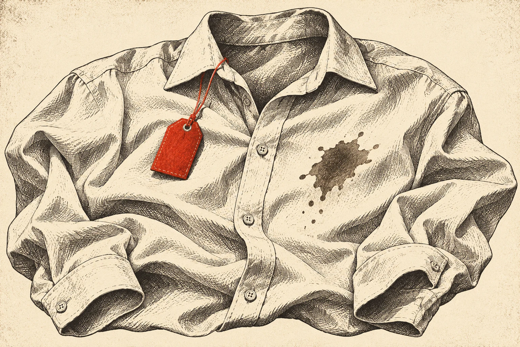

The replacement shirt**CAD 20**

**The Significant Five**University of Toronto MississaugaSTA304 · Survey research

From the survey

## Explore the evidence.

All respondents · n = 92

The student group filter updates the chart and its summary. Notes labelled “Full study” and the key findings use all 92 responses.

01Monthly budget 02Payment scenarios 03Three ratings

Student group

Survey scenario

Colour palette

### A clean shirt before presenting

You are on campus 20 minutes before an important presentation when you notice a large stain on your shirt. Would you pay $20 to change into a new shirt immediately, before anyone sees it?

Would pay · 57Would decline · 35

Reading the figure

### 62.0% would pay.

57 of 92 respondents in this view said they would pay $20 for a replacement shirt.

Full study · both groups · 92 respondents

Offline preview of the group’s survey results.

Full study · 92 respondents

## Key findings.

### Naming a price

When students named their own price for avoiding a conversation, 60 of 92 entered $0. The sample gives no clear evidence that students with larger budgets consistently offered more.

### Making a choice

For the $20 shirt, 57 of 92 said yes. For the $5 late arrival, 21 of 92 said yes, including 17 of 34 international and 4 of 58 domestic students. Each question changed both the price and the situation.

### Describing a feeling

Students who gave a high rating for one feeling tended to rate the others higher too. Across all three items, internal consistency was 0.793 on Cronbach’s alpha measure. These hypothetical answers cannot tell us whether those feelings or student status caused a payment choice.

Study notes

## Who answered?

The dataset contains 92 complete responses, including 58 domestic and 34 international students.

**How to interpret these results**

The proposal targeted the two Fall 2026 STA304 lecture sections at UTM and planned recruitment through Piazza by student status. Random selection within each group could not be verified. The results describe these respondents’ hypothetical choices. The two payment scenarios change both the price and the situation, so their difference cannot identify a price effect.

**Methods and sources**

The group’s final exploratory analysis used Spearman rank correlation for the two amounts, two-proportion z-tests for the scenarios, and Cronbach’s alpha for the three ratings. Its significance decisions used a Holm adjustment across 14 comparisons. For late arrival, 4 of 58 domestic respondents said yes. Under the hypothesis of equal payment rates, the smallest of the four expected counts was 7.76. A separate check using two-sided Fisher exact tests for the two scenarios and the same 14-test Holm adjustment also found a group difference for late arrival.

Source: The Significant Five’s cleaned survey, codebook, original proposal, and final exploratory data analysis (25 October 2026). All amounts are in Canadian dollars.